# Practical Session 1 - Visualization and Memory Management

Vlaad

updated on 4 October 2016

This is part of Practical Session 1. This document covers visualization and memory management.

# R Visualization

Advantages of data visualization:

1. Visual representation is more intuitive than a textual representation.
2. It includes a data summarization step.
3. “a picture is worth a thousand words”.

For this session we need to install and load the `ggplot2` package. We will also use the credit card data.

```r
#install.packages("ggplot2")
#install.packages("ggpthemes")
library(ggplot2)
require(ggthemes)
library(XLConnect)
# Load the data
creditcard <- readWorksheetFromFile("../data/default of credit card clients.xls", sheet="Data", startRow=2, startCol=2)
```

## Histogram, Scatter Plot, and Boxplot

We plot the histogram for the `LIMIT_BAL` variable

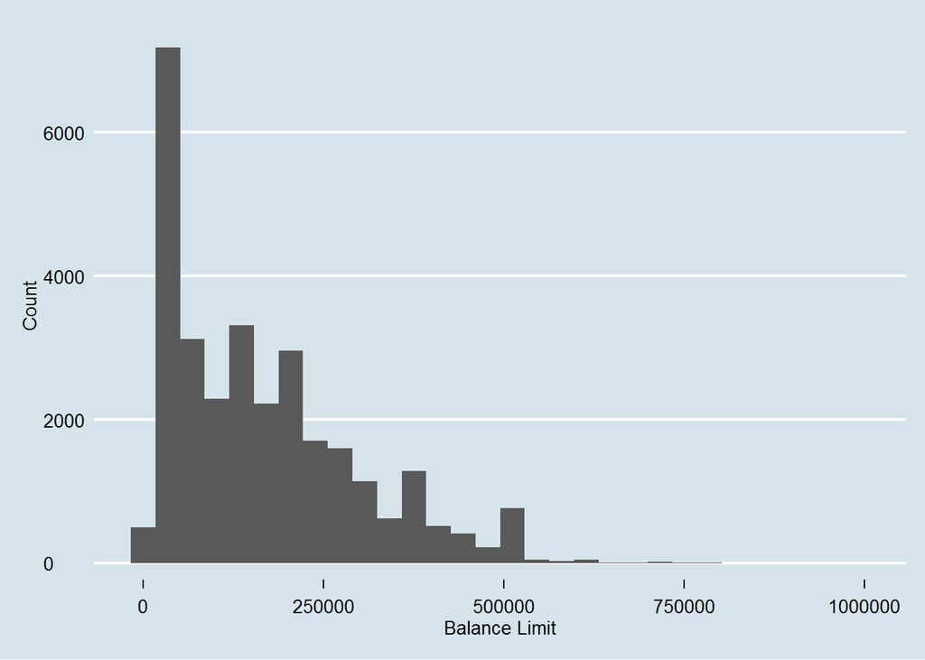

```r
ggplot(data=creditcard) + geom_histogram(aes(x= LIMIT_BAL)) + theme_economist() + ylab("Count") + xlab("Balance Limit")
```

Now plot the `LIMIT_BAL` against `AGE`

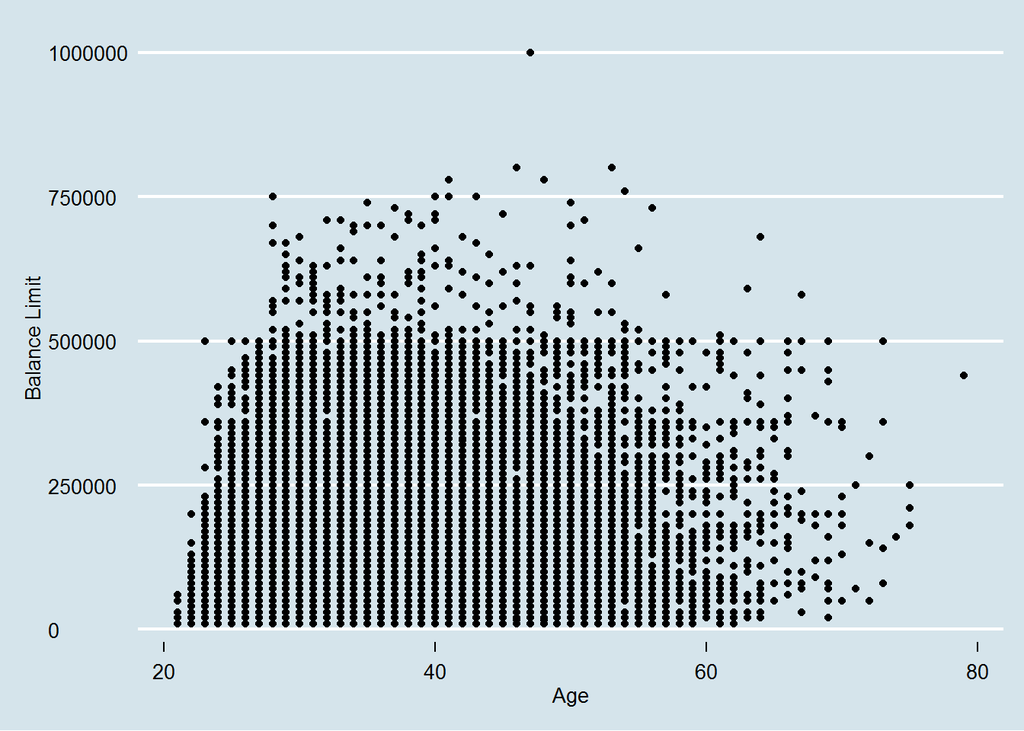

```r
ggplot(creditcard, aes(x=AGE, y=LIMIT_BAL)) + geom_point() + theme_economist() + ylab("Balance Limit") + xlab("Age")
```

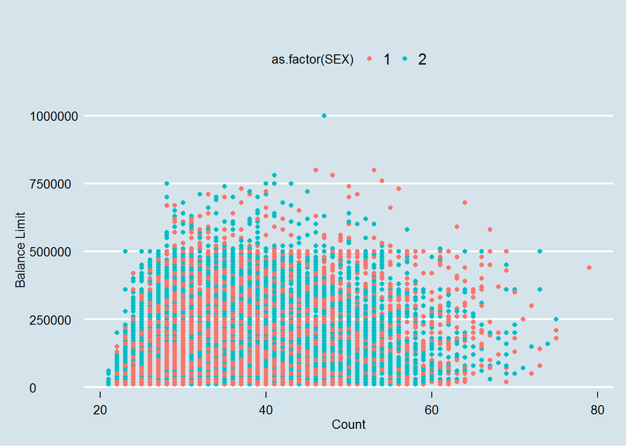

```r
#Add information about `SEX`
ggplot(creditcard, aes(x=AGE, y=LIMIT_BAL)) + geom_point(aes(color=as.factor(SEX))) + theme_economist() + xlab("Count") + ylab("Balance Limit")
```

Now let us create a box plot, comparing the `LIMIT_BAL` between sexes.

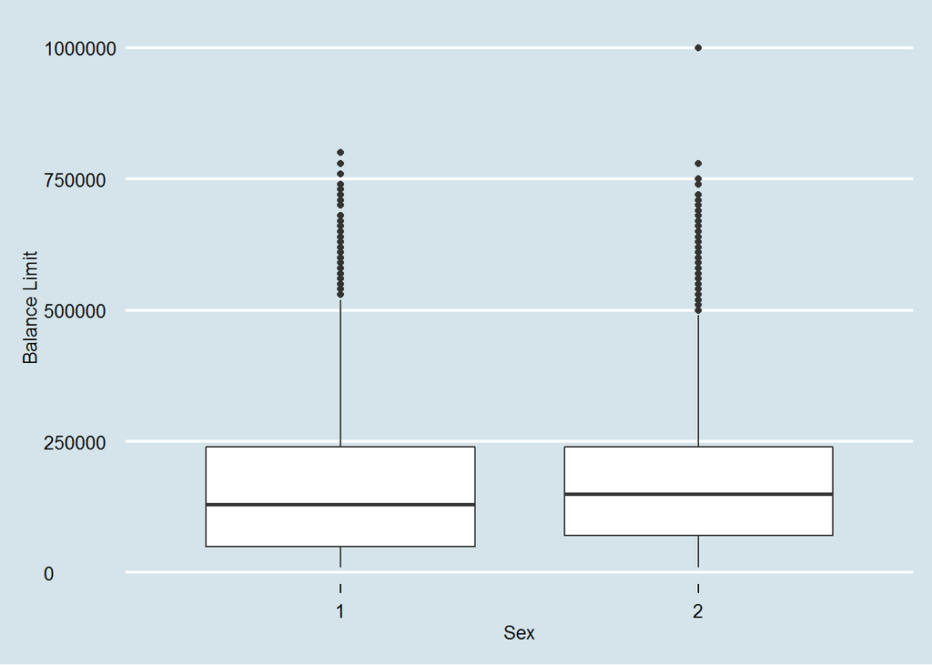

```r
ggplot(creditcard, aes(x=as.factor(SEX), y=LIMIT_BAL)) + geom_boxplot() + theme_economist() + ylab("Balance Limit") + xlab("Sex")
```

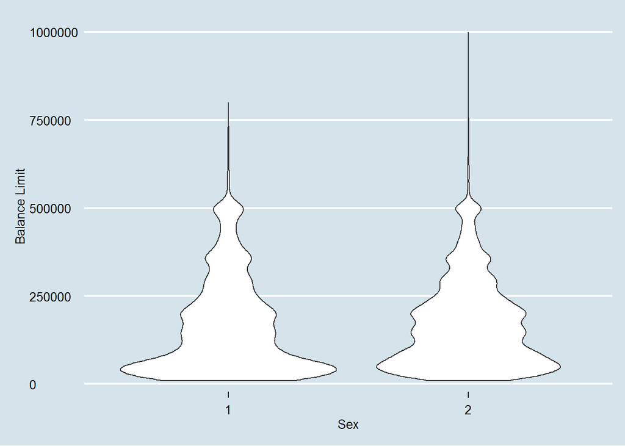

```r
# Using violin plot instead of box plot.
ggplot(creditcard, aes(x=as.factor(SEX), y=LIMIT_BAL)) + geom_violin() + theme_economist() + ylab("Balance Limit") + xlab("Sex")
```

# Memory Management in R

When dealing with large datasets being efficient with memory is crucial. So let us look at basic memory management in `R`. A useful function is `object_size()` from the package `pryr`.

```r
#install.packages("pryr")
library(pryr)

x<-1:1e6
object_size(x)
```

```
## 4 MB
```

```r
y<-list(x,x,x)
object_size(y)
```

```
## 4 MB
```

```r
object_size(x,y)
```

```
## 4 MB
```

> Q6 (Medium): Why is the combined sizes of x and y the same as y alone?

To remove an object in `R` use `rm()`.

Some useful tips:

- Use memory efficient objects whenever possible. For example, instead of a full matrix use a sparse matrix.
- Use the `gc()` for garbage collection. This process promptly returns memory to the operating system. This is usually done after removing a large object in `R`.
- There are some packages that are created to handle big datasets in `R`. For example, see the `ff` and `bigmemory` packages. We will discuss the use of these packages in the succeeding lab sessions.

# Next session preparation

In some scenarios, it is not advisable to import your full data in`R`. This could for example be useful if you have such a big data set that `R` can no longer hold the data in memory (RAM). It is more memory efficient to just import some parts of the data. This is made possible through the use of a database and connecting the database to `R`. Having a database also allows you to pose complicated queries on your dataset. We will use a SQLite database.